# Describing distributions of data

# Assignment Overview

There are a variety of conventional ways to visualize data - tables, histograms, bar graphs, etc. The purpose is always to examine the distribution of variables related to your research question. You will create a plot, follow up each graphic with a table of summary statistics (for quantitative variables) or frequency and proportion table (for categorical), and then a summary paragraph that brings it all together.

# Instructions

- Use the template provided: [RMD].
- Completely describe 2 categorical and 2 quantitative variables using
  - A table of summary statistics,
  - An appropriate plot with titles and axes labels,
  - A short paragraph description in full complete English sentences.

## Guidiance

# Submission

1. Upload the final PDF to `05 Univariate Graphing` folder in Google Drive with the file name: `univ_graphing_userid.pdf` by the due date.

# Example

This example uses the `mpg` data set from the `ggplot2` package.

```r
mpg <- ggplot2::mpg
```

## Example of a basic-level answer for a categorical variable

This example shows a draft style plot, direct computer output showing/copied. Poor grammar and/or sentence structure, no attempt at explaining what the variable means, extra unnecessary or incorrect information included. Typos.

> class

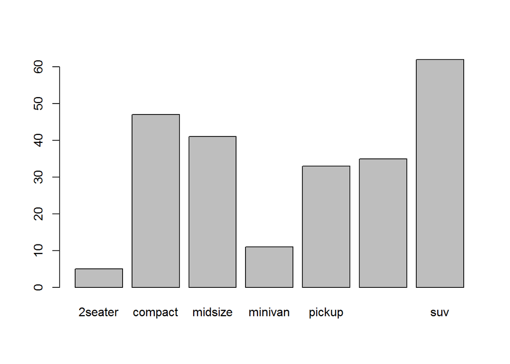

```
## mpg$class
##            Frequency Percent
## 2seater            5   2.137
## compact           47  20.085
## midsize           41  17.521
## minivan           11   4.701
## pickup            33  14.103
## subcompact        35  14.957
## suv               62  26.496
## Total            234 100.000
```

```r
library(descr)
freq(mpg$class)
```

> theres more suvs than compacts. 2% are 2seaters. there are 5 2seaters 47 cmpact 41 midize 11 minivans 33 pickups 35% subcompacts, 62 suv and 234 total cars.

## Example of a proficient-level answer for a categorical variable

This example has a cleaned up plot, full English sentences, useful text formatting of variable names and levels. Explained what the variable was named and what it measured.

> The `class` variable from the `mpg` data set is a catgorical variable that describes the type of vehicle being measured. Some levels of this categorical variable include *compact*, *pickup* and *suv*.

[figure not shown]

```r
library(sjPlot); library(ggplot2)
set_theme(base = theme_classic())
sjp.frq(mpg$class)
```

## Example of a basic-level answer for a quantiative variable

Quick and dirty plot being shown, summary table. No english description provided, no verbal explanation of what information was gained from these plots.

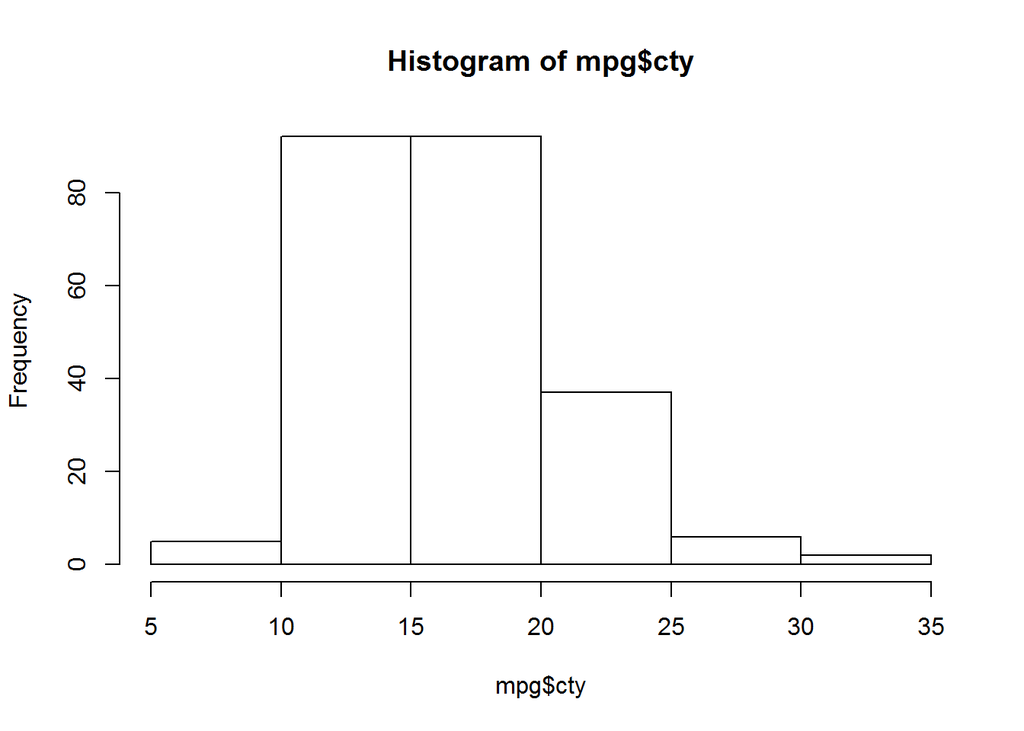

```r
hist(mpg$cty)
```

```r
summary(mpg$cty)
```

```
##    Min. 1st Qu.  Median    Mean 3rd Qu.    Max.
##    9.00   14.00   17.00   16.86   19.00   35.00
```

## Example of a proficient-level answer for a quantitative variable

This example uses a histogram with overlaid density curve, and a boxplot to understand the shape, location and to look for outliers. Table of summary statistics present in a nicely formatted way, digits rounded appropriately. Plot cleaned up with appropriate axis and titles.

> The `cty` variable records the miles per gallon (mpg) achieved during city driving. This is a quantititative numeric variable.

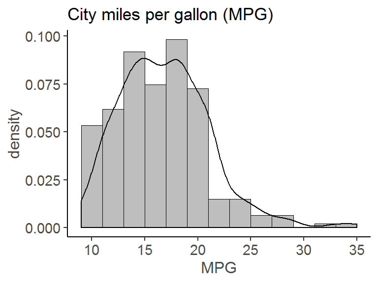

```r
ggplot(mpg, aes(x=cty)) + geom_histogram(aes(y=..density..), fill="grey", binwidth = 2) +
      geom_density()+ xlab("MPG") + ggtitle("City miles per gallon (MPG)")
```

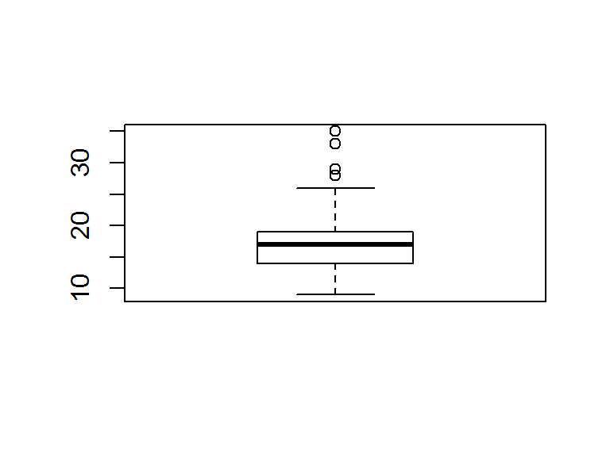

```r
boxplot(mpg$cty)
```

```r
knitr::kable(t(c(summary(mpg$cty), sd=sd(mpg$cty))), digits=1)
```

| Min. | 1st Qu. | Median | Mean | 3rd Qu. | Max. | sd |
| --- | --- | --- | --- | --- | --- | --- |
| 9 | 14 | 17 | 16.9 | 19 | 35 | 4.3 |

> The MPG in the city ranges from 9 to 35, unimodal and is slightly skewed right with a mean of 16.9 close to the median of 17 and a standard deviation of 4.3mpg. The boxplot indicates that there are at least 4 upper end outliers achieving a city MPG of approximately over 28 mpg.